# Rainfall, Fire, and Plant Abundance

###### Michael Cormier, Sage Wright

##### This Markdown records the R code used to analyze Australian ecological data from the TERN AEKOS data portal.

##### This data includes above-ground plant and seed abundance for *Trachymene glaucifolia* at 4 sites in the Simpson Desert of Australia. Rainfall measurements are also included. The data ranges in date from 2004 to 2011. The data was collected in an effort to study the influence of fire on the area after a 2001/2002 wild fire. For each site, there are 15 burned plots and 15 unburned plots. The REFORMATED data files are compatible with the code presented here; there is no difference between the two, except that the reformatted data files are already prepared for analysis.

##### This is the Original Data.

##### These are the [Edited Data Files](https://github.com/sagemwright/rainfall-fire-plant-abundance-bio465/blob/master/Reformated-Data.zip) used in this analysis.

### Data Preparation

#### 1. Load R packages

```r
library(readr)
library(stringr)
library(dplyr)
library(magrittr)
library(ggplot2)
```

#### 2. Read the data files

Things to be aware of:  
- CS, FR, MC, SS stand for Carlo Shitty, Field River, Main Camp, and South Site plots respectively.  
- Rainfall is measured in mm

```r
CS = read_csv("PLOT_CS.csv")
FR = read_csv("PLOT_FR.csv")
MC = read_csv("PLOT_MC.csv")
SS = read_csv("PLOT_SS.csv")
allRain = read_csv("All_rain_complete_R.csv")
```

#### 3. Early Rainfall

Rainfall measurements begin in May 1995 and end in Sep 2012. Abundance data begins at the beginning of 2004 and ends during 2011.  
The most recent wildfire at these sites occurred in 2001/2002.  
Since we have rainfall data before the abundance data was recorded, we calculated the mean of the recorded rainfall measurements at each site for six month periods from 2002 to 2004 in order to understand the rainfall patterns immediately following the wildfire.

##### Create a data frame of rainfall for the 2 years before *Trachymene glaucifolia* abundance data was recorded

Rainfall measurements will be split into 6 month intervals at each site and averaged.

```r
# Get rainfall data from 2002 - 2003
preRainfall = allRain[81:104,] #2002 - 2003

# 6 month means
CS_1st = mean(preRainfall$`Carlo Shitty`[1:6], na.rm = TRUE)
CS_2nd = mean(preRainfall$`Carlo Shitty`[7:12], na.rm = TRUE)
CS_3rd = mean(preRainfall$`Carlo Shitty`[13:18], na.rm = TRUE)
CS_4th = mean(preRainfall$`Carlo Shitty`[19:24], na.rm = TRUE)

FR_1st = mean(preRainfall$`Field River`[1:6], na.rm = TRUE)
FR_2nd = mean(preRainfall$`Field River`[7:12], na.rm = TRUE)
FR_3rd = mean(preRainfall$`Field River`[13:18], na.rm = TRUE)
FR_4th = mean(preRainfall$`Field River`[19:24], na.rm = TRUE)

MC_1st = mean(preRainfall$`Main Camp`[1:6], na.rm = TRUE)
MC_2nd = mean(preRainfall$`Main Camp`[7:12], na.rm = TRUE)
MC_3rd = mean(preRainfall$`Main Camp`[13:18], na.rm = TRUE)
MC_4th = mean(preRainfall$`Main Camp`[19:24], na.rm = TRUE)

SS_1st = mean(preRainfall$`South Site`[1:6], na.rm = TRUE)
SS_2nd = mean(preRainfall$`South Site`[7:12], na.rm = TRUE)
SS_3rd = mean(preRainfall$`South Site`[13:18], na.rm = TRUE)
SS_4th = mean(preRainfall$`South Site`[19:24], na.rm = TRUE)

### Make a new data frame with early rain info
earlyRain = data.frame(Date = c("Jan02-Jun02", "Jul02-Dec02", "Jan03-Jun03", "Jul03-Dec03"),
                       "Carlo Shitty" = c(CS_1st, CS_2nd, CS_3rd, CS_4th),
                       "Field River" = c(FR_1st, FR_2nd, FR_3rd, FR_4th),
                       "Main Camp" = c(MC_1st, MC_2nd, MC_3rd, MC_4th),
                       "South Site" = c(SS_1st, SS_2nd, SS_3rd, SS_4th))

print(earlyRain)
```

```
##          Date Carlo.Shitty Field.River Main.Camp South.Site
## 1 Jan02-Jun02    10.700000    9.333333  0.300000       26.1
## 2 Jul02-Dec02    10.233333    0.400000  5.366667        NaN
## 3 Jan03-Jun03    20.840000    1.500000 15.933333        3.6
## 4 Jul03-Dec03     8.833333    2.800000  7.333333        NaN
```

#### 5. Curate the abundance data

```r
## Total Averages
totalMeans = data.frame(CS$TOTAL_AVERAGE, FR$TOTAL_AVERAGE, MC$TOTAL_AVERAGE, SS$TOTAL_AVERAGE[1:30])
total_MeanSites = rowMeans(totalMeans, na.rm = TRUE)

### BURNED PLOTS
## Average Burned
burnedMeans = data.frame(CS$TOTAL_BURNED, FR$TOTAL_BURNED, MC$TOTAL_BURNED, SS$TOTAL_BURNED[1:30])
total_burned_means = rowMeans(burnedMeans)

## Average Seed Abundance Burned
seed_burnedMeans = data.frame(CS$BURNED_AVERAGE_SEED, FR$BURNED_AVERAGE_SEED, MC$BURNED_AVERAGE_SEED, SS$BURNED_AVERAGE_SEED[1:30])
total_seed_burned = rowMeans(seed_burnedMeans)

## Average Plant Abundance Burned
plant_burnedMeans = data.frame(CS$BURNED_AVERAGE, FR$BURNED_AVERAGE, MC$BURNED_AVERAGE, SS$BURNED_AVERAGE[1:30])
total_plant_burned = rowMeans(plant_burnedMeans)

### UNBURNED PLOTS
## Average Unburned
unburnedMeans = data.frame(CS$TOTAL_UNBURNED, FR$TOTAL_UNBURNED, MC$TOTAL_UNBURNED, SS$TOTAL_UNBURNED[1:30])
total_unburned_means = rowMeans(unburnedMeans)

## Average Seed Abundance
SA_means = data.frame(CS$AVERAGE_SEED, FR$AVERAGE_SEED, MC$AVERAGE_SEED, SS$AVERAGE_SEED[1:30])
total_SA_means = rowMeans(SA_means)

## Average Plant Abundance
PA_means = data.frame(CS$AVERAGES, FR$AVERAGES, MC$AVERAGES, SS$AVERAGES[1:30])
total_PA_means = rowMeans(PA_means)
```

#### 6. Alter the format of dates so files can be joined properly

We had to manipulate the date format in each data file so that they were be able to be joined together.

```r
allRain_fix <- allRain %>%
  mutate(X1 = parse_datetime(X1, "%b-%y"))
CS_fix <- CS %>%
  mutate(Date = parse_datetime(Date, "%y-%b"))
FR_fix <- FR %>%
  mutate(Date = parse_datetime(Date, "%y-%b"))
MC_fix <- MC %>%
  mutate(Date = parse_datetime(Date, "%y-%b"))
SS_fix <- SS %>%
  mutate(Date = parse_datetime(Date, "%y-%b"))
```

#### 7. Filter rain fall by region dates

```r
CS_rain = allRain_fix[which(allRain_fix$X1 %in% CS_fix$Date),]
FR_rain = allRain_fix[which(allRain_fix$X1 %in% FR_fix$Date),]
MC_rain = allRain_fix[which(allRain_fix$X1 %in% MC_fix$Date),]
SS_rain = allRain_fix[which(allRain_fix$X1 %in% SS_fix$Date),]
```

#### 8. Combine all rain data points and average them

```r
filteredRain = inner_join(CS_rain, FR_rain) %>%
  inner_join(MC_rain) %>%
  inner_join(SS_rain)

averageFilteredRain = rowMeans(filteredRain[,2:5], na.rm = TRUE)
```

### Data Analysis

#### 1. Plot combined rain fall and total average

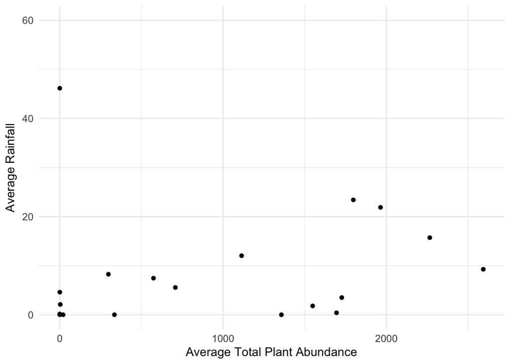

```r
# Create a temporary data frame for the graph
total <- data.frame(total_MeanSites, averageFilteredRain)

ggplot(total, aes(x = total_MeanSites, y = averageFilteredRain)) +
  geom_point(na.rm=TRUE) +
  ylim(0, 60) +
  labs(x = "Average Total Plant Abundance", y = "Average Rainfall") +
  theme_minimal() +
  theme(axis.title = element_text(size=12), axis.text = element_text(size=10))
```

```r
general <- cor.test(total_MeanSites, averageFilteredRain, method = "pearson", alternative = "greater")
print(general)
```

```
##
##  Pearson's product-moment correlation
##
## data:  total_MeanSites and averageFilteredRain
## t = 0.54641, df = 17, p-value = 0.2959
## alternative hypothesis: true correlation is greater than 0
## 95 percent confidence interval:
##  -0.2720474  1.0000000
## sample estimates:
##       cor
## 0.1313762
```

We then moved forward and calculated the correlation for subcategories of data; primarily a division between unburned plots and burned plots in addition to seed abundance and above-ground plant abundance. There were a total of five initial correlation tests conducted, including the one described above.

#### 2. Initial Correlation Tests

```r
## Correlation between rain fall and mean seed abundance
mean_seed <- cor.test(total_SA_means, averageFilteredRain, method = "pearson", alternative = "greater")
print(mean_seed)
```

```
##
##  Pearson's product-moment correlation
##
## data:  total_SA_means and averageFilteredRain
## t = 0.76359, df = 6, p-value = 0.237
## alternative hypothesis: true correlation is greater than 0
## 95 percent confidence interval:
##  -0.4042387  1.0000000
## sample estimates:
##       cor
## 0.2976103
```

```r
## Correlation between rain fall and mean aboveground plant abundance
mean_plant <- cor.test(total_PA_means, averageFilteredRain, method = "pearson", alternative = "greater")
print(mean_plant)
```

```
##
##  Pearson's product-moment correlation
##
## data:  total_PA_means and averageFilteredRain
## t = -0.21532, df = 12, p-value = 0.5834
## alternative hypothesis: true correlation is greater than 0
## 95 percent confidence interval:
##  -0.5065366  1.0000000
## sample estimates:
##         cor
## -0.06203823
```

```r
## Correlation between rainfall and average combined plant abundance at burned sites
mean_burned <- cor.test(total_burned_means, averageFilteredRain, method = "pearson", alternative = "greater")
print(mean_burned)
```

```
##
##  Pearson's product-moment correlation
##
## data:  total_burned_means and averageFilteredRain
## t = 2.4192, df = 12, p-value = 0.01618
## alternative hypothesis: true correlation is greater than 0
## 95 percent confidence interval:
##  0.1541388 1.0000000
## sample estimates:
##       cor
## 0.5725574
```

```r
## Correlation between rainfall and average combined plant abundance at unburned sites
mean_unburned <- cor.test(total_unburned_means, averageFilteredRain, method = "pearson", alternative = "greater")
print(mean_unburned)
```

```
##
##  Pearson's product-moment correlation
##
## data:  total_unburned_means and averageFilteredRain
## t = 0.62611, df = 12, p-value = 0.2715
## alternative hypothesis: true correlation is greater than 0
## 95 percent confidence interval:
##  -0.3060385  1.0000000
## sample estimates:
##       cor
## 0.1778615
```

After noticing that there was a statistically significant correlation between rainfall and average combined plant abundance at burned sites, we wanted to see if which was more significantly correlated: seed abundance or aboveground plant abundance.

```r
## Correlation between rainfall and mean seed abundance at burned sites
burned_seed <- cor.test(total_seed_burned, averageFilteredRain, method = "pearson", alternative = "greater")
print(burned_seed)
```

```
##
##  Pearson's product-moment correlation
##
## data:  total_seed_burned and averageFilteredRain
## t = 2.7271, df = 6, p-value = 0.01716
## alternative hypothesis: true correlation is greater than 0
## 95 percent confidence interval:
##  0.2200363 1.0000000
## sample estimates:
##       cor
## 0.7439623
```

```r
## Correlation between rainfall and mean aboveground plant abundance at burned sites
burned_plant <- cor.test(total_plant_burned, averageFilteredRain, method = "pearson", alternative = "greater")
print(burned_plant)
```

```
##
##  Pearson's product-moment correlation
##
## data:  total_plant_burned and averageFilteredRain
## t = -0.35525, df = 12, p-value = 0.6357
## alternative hypothesis: true correlation is greater than 0
## 95 percent confidence interval:
##  -0.5358505  1.0000000
## sample estimates:
##        cor
## -0.1020182
```

Here, we can notice that seeds were more strongly correlated with rainfall. We next decided to graph these two significant correlations.

### Graphing Significant Correlations

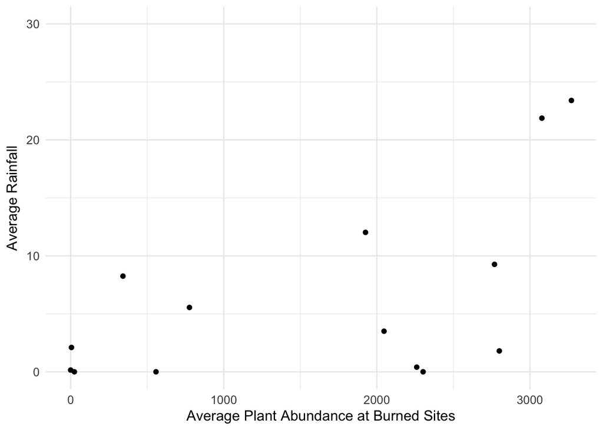

```r
## Plot rainfall and burned average
total <- data.frame(total_burned_means, averageFilteredRain)
ggplot(total, aes(x = total_burned_means, y = averageFilteredRain)) +
  geom_point(na.rm=TRUE) +
  ylim(0, 30) +
  labs(x = "Average Plant Abundance at Burned Sites", y = "Average Rainfall") +
  theme_minimal() +
  theme(axis.title = element_text(size=12), axis.text = element_text(size=10))
```

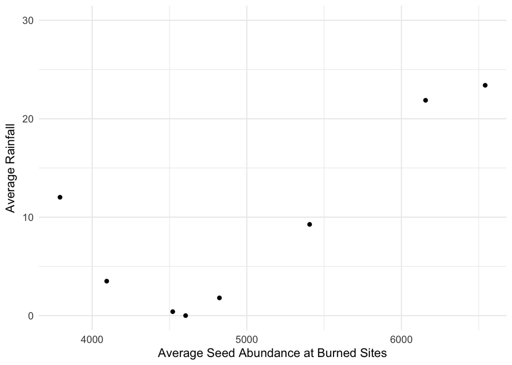

```r
## Plot rainfall and burned seed average
total <- data.frame(total_seed_burned, averageFilteredRain)
ggplot(total, aes(x = total_seed_burned, y = averageFilteredRain)) +
  geom_point(na.rm=TRUE) +
  labs(x = "Average Seed Abundance at Burned Sites", y = "Average Rainfall") +
  ylim(0,30) +
  theme_minimal() +
  theme(axis.title = element_text(size=12), axis.text = element_text(size=10))
```

### Multiple Test Correction

We realized it was necessary to run multiple test corrections. We chose the FDR multiple test correction because we felt that the Bonferroni correction would be too stringent for this study.

```r
p_values <- c(general$p.value, mean_seed$p.value, mean_plant$p.value, mean_burned$p.value, mean_unburned$p.value, burned_seed$p.value, burned_plant$p.value)

corrected_p_values <- p.adjust(p_values, method = "fdr", n = length(p_values))
print(corrected_p_values)
```

```
## [1] 0.41431706 0.41431706 0.63571771 0.06005367 0.41431706 0.06005367
## [7] 0.63571771
```

Following the multiple test correction, we noticed that the two values that were significant were no longer below the 0.05 significance threshold. We decided to create combined graphics that would show the relationship between seed abundance, aboveground plant abundance, and rainfall.

### Combined graphics: Seed, plant, and rainfall

*Data will be log transformed to allow seed abundance, plant abundance, and rain to all fit on the same graph

We started by plotting all of the variables for all four sites. See the attached Markdown file to see the code to reproduce these graphics.

#### 1. Combined Carlo Shitty seed, plant, and rain. Previous 2 years of rain added

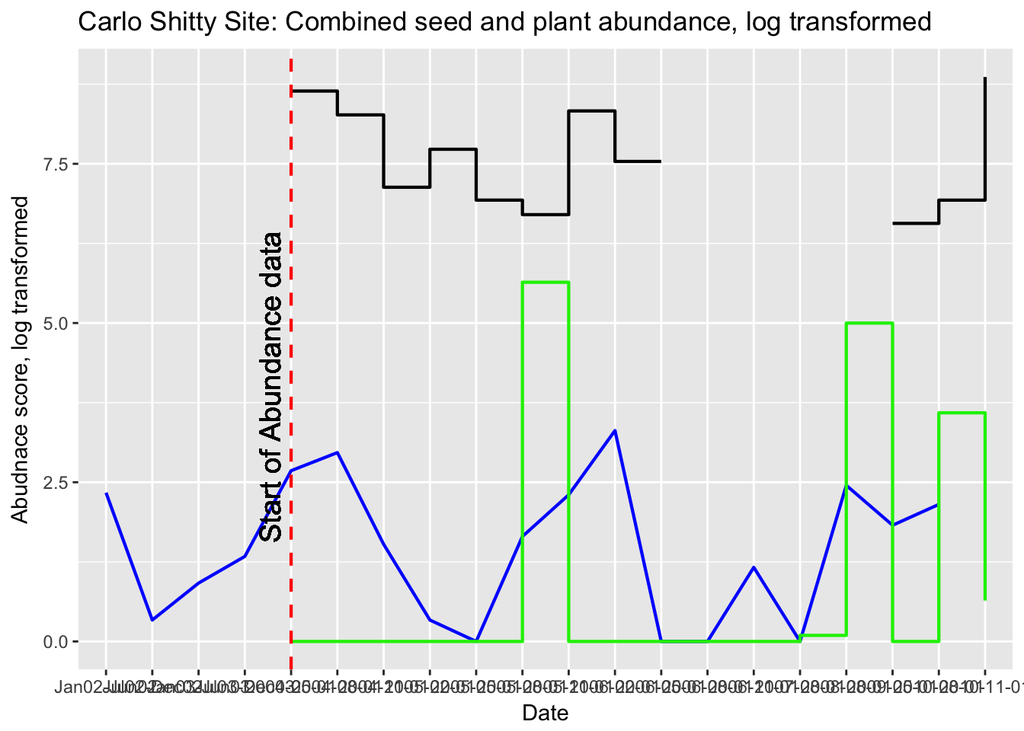

#### 2. Combined Field River seed, plant, and rain. Previous 2 years of rain added

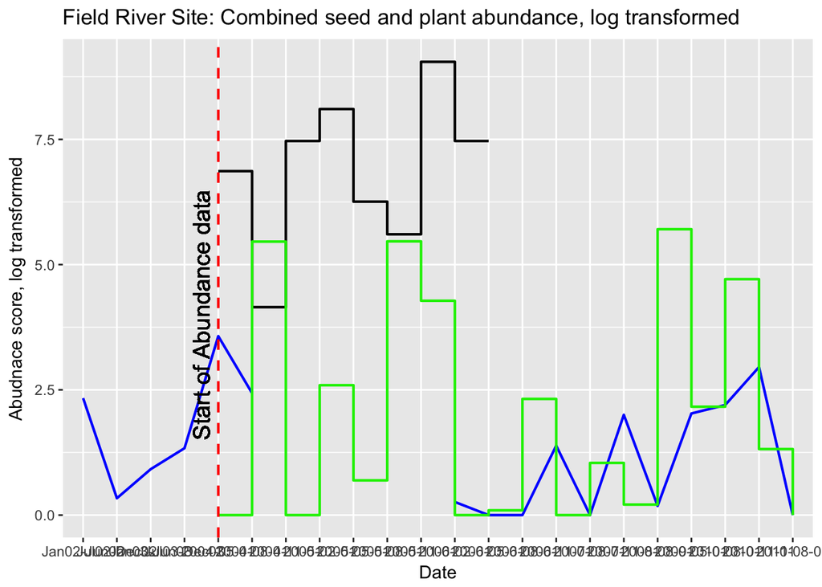

#### 3. Combined Main Camp seed, plant, and rain. Previous 2 years of rain added

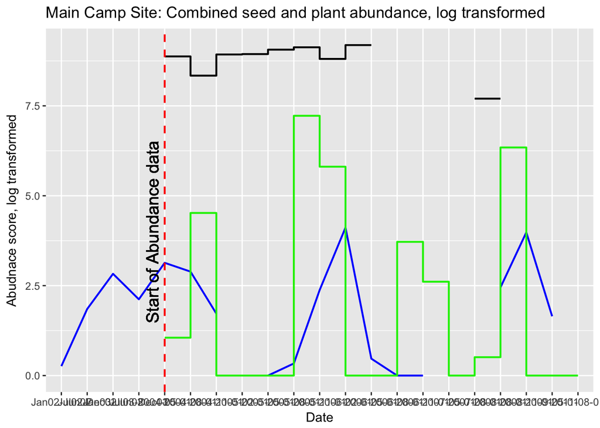

#### 4. Combined South Site seed, plant, and rain. Previous 2 years of rain added

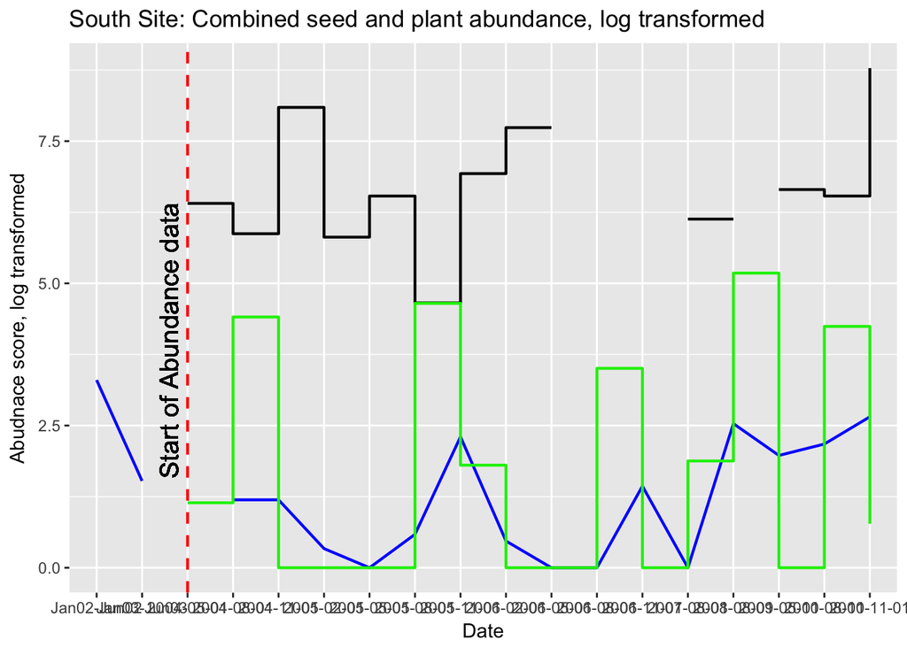

We then decided to graph these variables but without respect to site.

#### 5. Mean plant and rain. 2 previous rainfall years added.

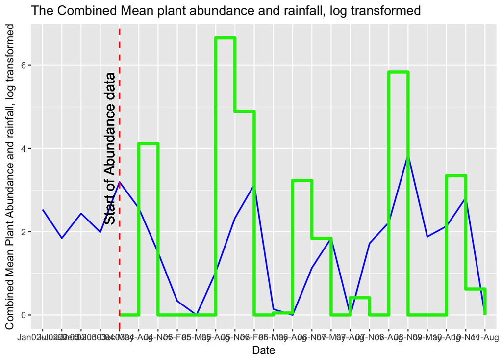